# Tipología y ciclo de vida de los datos: Práctica 2

Jorge Marchán Gutiérrez

Rafael Jiménez Sarmentero

mayo 2022

# 1 Descripción del dataset. ¿Por qué es importante y qué pregunta/problema pretende responder?

El dataset elegido para la realización de la práctica ha sido el de [Titanic](https://www.kaggle.com/competitions/titanic/overview) que contiene una serie de datos sobre los pasajeros del Titanic, entre otras cosas, si finalmente sobrevivieron o no, los datos se dividen en varios ficheros `train.csv` y `test.csv`, además de un tercer fichero `gender_submission.csv` que para la realización de esta práctica no es necesario, ya que es un ejemplo de fichero de envío para la competición, de Kaggle. A nosotros nos interesa el fichero de `train.csv`, sobre el cual vamos a realizar las tareas de limpieza y análisis.

Con este *dataset* se podrían encontrar relaciones entre supervivencia y edad, o supervivencia y género, entre otras, o se podría utilizar para entrenar un modelo capaz de predecir, si una persona con unas características determinadas sobrevivió al accidente o no.

```r
data <- read.csv("./input_files/train.csv", header = TRUE, stringsAsFactors = FALSE)
dim(data)
```

```
## [1] 891  12
```

```r
head(data)
```

```
##   PassengerId Survived Pclass
## 1           1        0      3
## 2           2        1      1
## 3           3        1      3
## 4           4        1      1
## 5           5        0      3
## 6           6        0      3
##                                                  Name    Sex Age SibSp Parch
## 1                             Braund, Mr. Owen Harris   male  22     1     0
## 2 Cumings, Mrs. John Bradley (Florence Briggs Thayer) female  38     1     0
## 3                              Heikkinen, Miss. Laina female  26     0     0
## 4        Futrelle, Mrs. Jacques Heath (Lily May Peel) female  35     1     0
## 5                            Allen, Mr. William Henry   male  35     0     0
## 6                                    Moran, Mr. James   male  NA     0     0
##             Ticket    Fare Cabin Embarked
## 1        A/5 21171  7.2500              S
## 2         PC 17599 71.2833   C85        C
## 3 STON/O2. 3101282  7.9250              S
## 4           113803 53.1000  C123        S
## 5           373450  8.0500              S
## 6           330877  8.4583              Q
```

Podemos observar que el *dataset* contiene 891 filas y 12 atributos, a continuación vamos a ver los tipos de atributos y su significado

```r
str(data)
```

```
## 'data.frame':    891 obs. of  12 variables:
##  $ PassengerId: int  1 2 3 4 5 6 7 8 9 10 ...
##  $ Survived   : int  0 1 1 1 0 0 0 0 1 1 ...
##  $ Pclass     : int  3 1 3 1 3 3 1 3 3 2 ...
##  $ Name       : chr  "Braund, Mr. Owen Harris" "Cumings, Mrs. John Bradley (Florence Briggs Thayer)" "Heikkinen, Miss. Laina" "Futrelle, Mrs. Jacques Heath (Lily May Peel)" ...
##  $ Sex        : chr  "male" "female" "female" "female" ...
##  $ Age        : num  22 38 26 35 35 NA 54 2 27 14 ...
##  $ SibSp      : int  1 1 0 1 0 0 0 3 0 1 ...
##  $ Parch      : int  0 0 0 0 0 0 0 1 2 0 ...
##  $ Ticket     : chr  "A/5 21171" "PC 17599" "STON/O2. 3101282" "113803" ...
##  $ Fare       : num  7.25 71.28 7.92 53.1 8.05 ...
##  $ Cabin      : chr  "" "C85" "" "C123" ...
##  $ Embarked   : chr  "S" "C" "S" "S" ...
```

Los atributos que encontramos son:

- **PassengerId**: Es el identificador interno del pasajero, de tipo entero
- **Survived**: Es un valor de tipo entero que nos indica si el pasajero ha sobrevivido o no (0 o 1)
- **Pclass**: El tipo de billete que ha adquirido el pasajero, tipo entero (1 = Primera, 2 = Segunda, 3 = Tercera)
- **Name**: El nombre del pasajero, tipo char
- **Sex**: El género del pasajero, tipo char (male o female)
- **Age**: La edad del pasajero, tipo number
- **SibSp**: El numero de hermanos y conyuges que hay abordo en el Titanic, tipo entero
- **Parch**: El número de padres e hijos que hay abordo en el Titanic, tipo entero
- **Ticket**: El identificador del billete, tipo char
- **Fare**: El precio del billete, tipo number
- **Cabin**: El código del camarote, tipo char
- **Embarked**: El puerto donde embarco el pasajero, tipo char (C = Cherbourg, Q = Queenstown, S = Southampton)

# 2 Integración y selección de los datos de interés a analizar. Puede ser el resultado de adicionar diferentes datasets o una subselección útil de los datos originales, en base al objetivo que se quiera conseguir.

De los atributos presentados, sin realizar ningún trabajo previo, consideramos que la siguiente lista de atributos no es relevante para el análisis estadístico que queremos llevar a cabo:

- **PassengerId**: La podemos eliminar del conjunto de datos ya que no contribuye a la supervivencia del pasajero
- **Ticket**: Por los mismos de PassengerId, consideramos que los identificadores internos no afectan a la supervivencia
- **Name**: Por si solo el nombre del pasajero creemos que no aporta nada a la supervivencia del mismo, sin embargo observamos que todos los nombres siguen un formato determinado y que todos contienen el titulo que se aplica a la persona, por lo tanto podríamos extraer esta característica para contar con un *dataset* con más información con la que trabajar.
- **Cabin**: Del camarote podemos llegar a saber que pasajeros viajaban en el mismo y si han sobrevivido o no, por lo tanto podemos saber si el camarote o el tipo de camarote estan relacionados con una mayor supervivencia.
- **SibSp y Parch**: De estas dos variables podemos extraer una sola, que hace referencia al numero de familiares que el pasajero tenia a bordo.

# 3 Limpieza de los datos.

## 3.1 ¿Los datos contienen ceros o elementos vacíos? Gestiona cada uno de estos casos.

Del análisis del fichero que contiene el dataset `train.csv` podemos extraer la siguiente información:

1. Algunas cadenas de caracteres tienen espacios en blanco al inicio y/o final.
2. Los valores decimales están separados por el caracter “.”.
3. La edad puede contener valores decimales al ser de tipo number y no entero.
4. El separador de columnas es el caracter “,”.

Para la limpieza de los datos resulta interesante conocer que atributos contienen valores vacios

```r
colSums(data == "")
```

```
## PassengerId    Survived      Pclass        Name         Sex         Age
##           0           0           0           0           0          NA
##       SibSp       Parch      Ticket        Fare       Cabin    Embarked
##           0           0           0           0         687           2
```

Con esta información y con lo que conocemos del dataset podemos concluir que las siguientes transformaciones serían interesantes con el objetivo de facilitar el análisis:

1. El atributo `Survived` debería ser un factor debido a que es cualitativa con valores `1` y `0`
2. El atributo `Pclass` debería ser un factor debido a que es cualitativa con valores `1`, `2` y `3`
3. El atributo `Sex` debería ser un factor debido a que es cualitativa con valores `male` y `female`
4. El atributo `Embarked` debería ser un factor debido a que es cualitativa con valores `C`, `Q` y `S`, además de que deberiamos cambiar los valores vacios por `NA`
5. El atributo `Cabin` contiene valores vacios por lo que hay que reemplazarlos por `NA`.

En primer lugar, deberiamos reemplazar los valores que consideramos vacios por `NA`

```r
data$Cabin[data$Cabin == ""] <- NA
data$Embarked[data$Embarked == ""] <- NA
```

Comprobamos ahora cuántos datos vacíos (NA) tiene cada atributo:

```r
colSums(is.na(data))
```

```
## PassengerId    Survived      Pclass        Name         Sex         Age
##           0           0           0           0           0         177
##       SibSp       Parch      Ticket        Fare       Cabin    Embarked
##           0           0           0           0         687           2
```

```r
data$Survived <- as.factor(data$Survived)
data$Pclass <- as.factor(data$Pclass)
data$Sex <- as.factor(data$Sex)
data$Embarked <- as.factor(data$Embarked)

str(data)
```

```
## 'data.frame':    891 obs. of  12 variables:
##  $ PassengerId: int  1 2 3 4 5 6 7 8 9 10 ...
##  $ Survived   : Factor w/ 2 levels "0","1": 1 2 2 2 1 1 1 1 2 2 ...
##  $ Pclass     : Factor w/ 3 levels "1","2","3": 3 1 3 1 3 3 1 3 3 2 ...
##  $ Name       : chr  "Braund, Mr. Owen Harris" "Cumings, Mrs. John Bradley (Florence Briggs Thayer)" "Heikkinen, Miss. Laina" "Futrelle, Mrs. Jacques Heath (Lily May Peel)" ...
##  $ Sex        : Factor w/ 2 levels "female","male": 2 1 1 1 2 2 2 2 1 1 ...
##  $ Age        : num  22 38 26 35 35 NA 54 2 27 14 ...
##  $ SibSp      : int  1 1 0 1 0 0 0 3 0 1 ...
##  $ Parch      : int  0 0 0 0 0 0 0 1 2 0 ...
##  $ Ticket     : chr  "A/5 21171" "PC 17599" "STON/O2. 3101282" "113803" ...
##  $ Fare       : num  7.25 71.28 7.92 53.1 8.05 ...
##  $ Cabin      : chr  NA "C85" NA "C123" ...
##  $ Embarked   : Factor w/ 3 levels "C","Q","S": 3 1 3 3 3 2 3 3 3 1 ...
```

Podemos extraer un atributo nuevo que nos indique el tamaño de la familia que viaja a bordo de cada pasajero, de cara al analisis posterior es más interesante tener el dato agrupado en un único atributo que en varios.

```r
data$Fnumber <- data$SibSp + data$Parch
data$SibSp <- NULL
data$Parch <- NULL
```

Vamos a comprobar visualmente si puede existir una relacion entre la variable `Survived` y el número de familiares

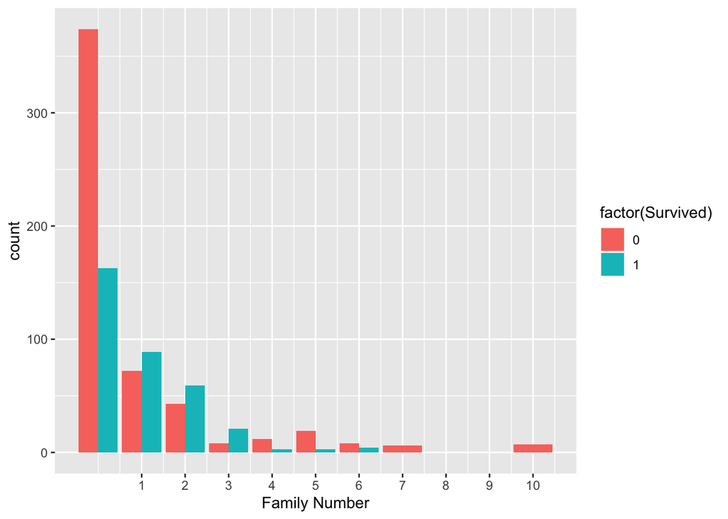

```r
if (!require('ggplot2')) install.packages('ggplot2'); library('ggplot2')
ggplot(data, aes(x = Fnumber, fill = factor(Survived))) +
  geom_bar(stat='count', position='dodge') +
  scale_x_continuous(breaks=c(1:11)) +
  labs(x = 'Family Number')
```

Observando los resultados nos damos cuenta de que los pasajeros que viajaban solos tenian más probabilidades de no sobrevivir que de sobrevivir, así como también ocurre con los pasajeros de más de 3 familiares a bordo, por lo que podemos crear tres categorias.

```r
data$Ftype[data$Fnumber == 0] <- 'single'
data$Ftype[data$Fnumber < 4 & data$Fnumber > 0] <- 'small'
data$Ftype[data$Fnumber >= 4] <- 'large'

data$Ftype <- as.factor(data$Ftype)
```

## 3.2 Identifica y gestiona los valores extremos.

Tenemos tres atributos numéricos: `Age`, `Fare` y `Fnumber` a continuación vamos a visualizar con boxplot cada una de las variables y a realizar su análisis para determinar si los valores extremos son correctos o son fallos.

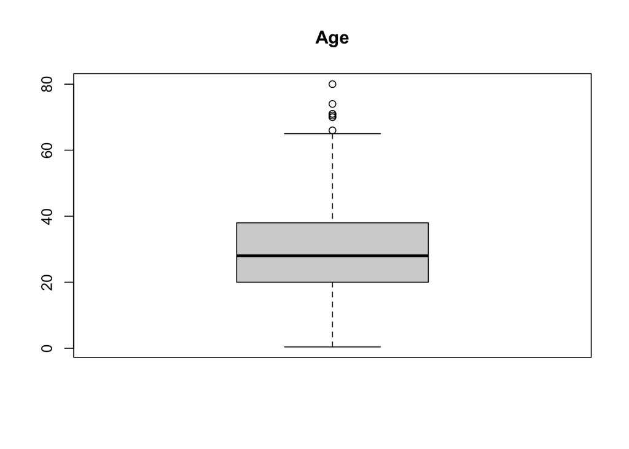

```r
boxplot(data$Age, main="Age")
```

```r
boxplot.stats(data$Age)$out
```

```
## [1] 66.0 71.0 70.5 71.0 80.0 70.0 70.0 74.0
```

Del atributo `Age` nos muestra que los valores extremos son aquellos que están por encima de 66 años, sin embargo no observamos ningun valor que aparentemente sea incorrecto, podemos extraer la conclusion de que era raro ver pasajeros de más de 66 años, por lo tanto estos datos no necesitan ser tratados.

Vamos a analizar ahora los valores extremos del atributo `Fare`

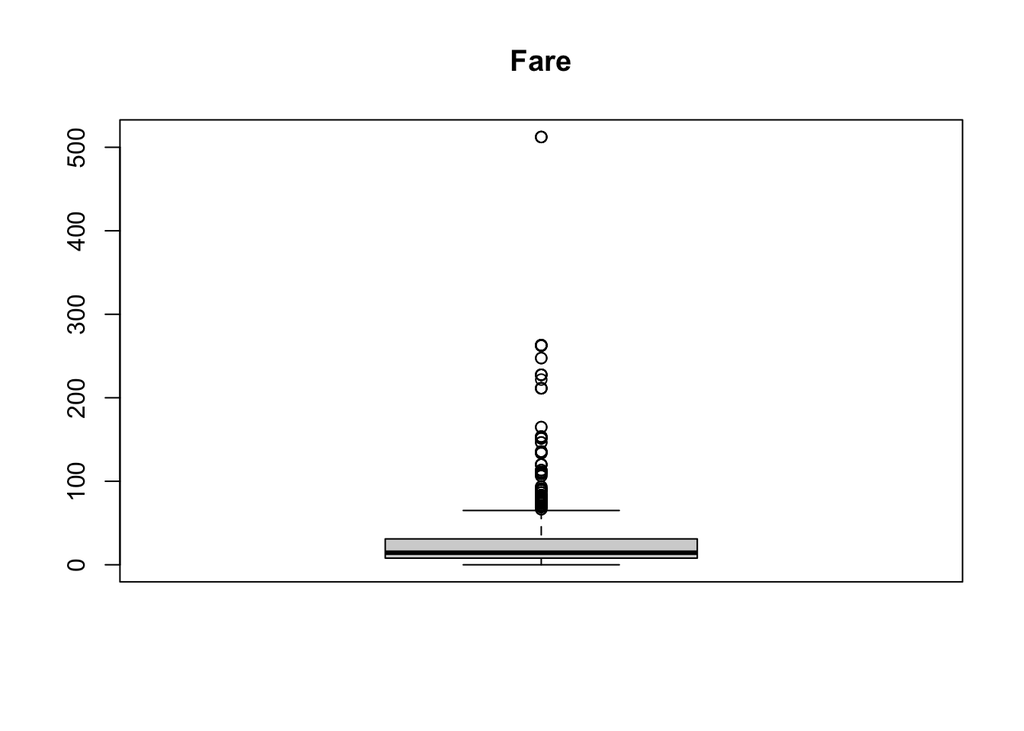

```r
boxplot(data$Fare, main="Fare")
```

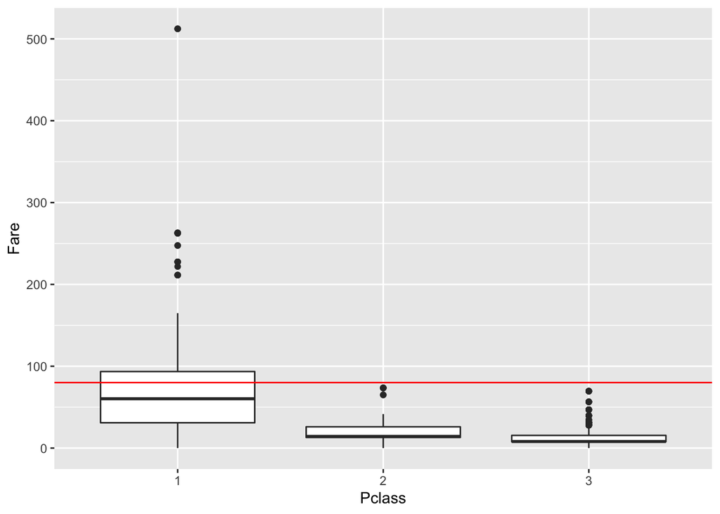

```r
ggplot(data, aes(x=Pclass, y=Fare)) +
  geom_boxplot() +
  geom_hline(aes(yintercept=80), colour='red')
```

```r
print(data[data$Fare > 200,])
```

```
##     PassengerId Survived Pclass
## 28           28        0      1
## 89           89        1      1
## 119         119        0      1
## 259         259        1      1
## 300         300        1      1
## 312         312        1      1
## 342         342        1      1
## 378         378        0      1
## 381         381        1      1
## 439         439        0      1
## 528         528        0      1
## 558         558        0      1
## 680         680        1      1
## 690         690        1      1
```

[output cut: 48 more lines]

Observamos como los valores considerados outliers para `Fare` están asociados con la clase en la que viajan, mientras más alta es la clase y mayor numero de pasajeros por billete, más alta es la tarifa, por lo tanto, los valores extremos en este atributo, son valores que consideramos válidos.

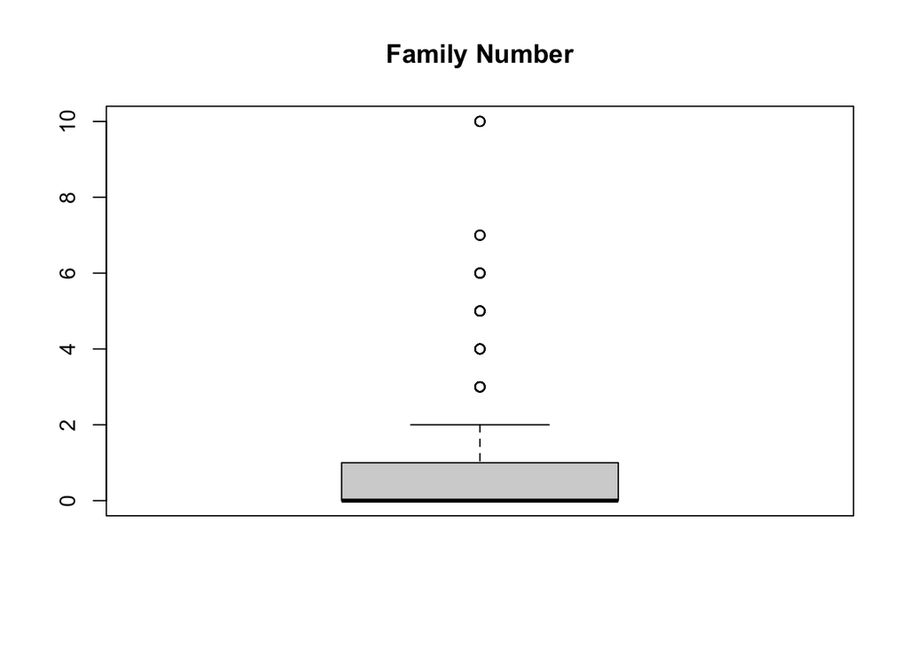

```r
boxplot(data$Fnumber, main="Family Number")
```

```r
boxplot.stats(data$Fnumber)$out
```

```
##  [1]  4  6  5  4  6  5  3  5  3  7  5  6  7  3  4  5  3  6  4 10  5  5  5  4 10
## [26]  6  3 10  4  6  6  5  5  3  3  4 10  5  5  4  7  3  4  3  4  5  5  3  3  3
## [51]  3  7  4  3  3  6  6  4  3  3  6  3  3  5  5  5  3  7  7  3  5  3  4  4  3
## [76]  3  4  3  5  3 10  3  6  5  5 10  6  3 10  5  3
```

Observamos como el boxplot nos cataloga como valores extremos todos aquellos pasajeros que viajasen con 3 familiares más, sin embargo no parece ser un dato incorrecto, quizá 10 familiares es un poco sospechoso, veamos los pasajeros con Fnumber = 10 existentes en el dataset

```r
data[data$Fnumber == 10,]
```

```
##     PassengerId Survived Pclass                              Name    Sex Age
## 160         160        0      3        Sage, Master. Thomas Henry   male  NA
## 181         181        0      3      Sage, Miss. Constance Gladys female  NA
## 202         202        0      3               Sage, Mr. Frederick   male  NA
## 325         325        0      3          Sage, Mr. George John Jr   male  NA
## 793         793        0      3           Sage, Miss. Stella Anna female  NA
## 847         847        0      3          Sage, Mr. Douglas Bullen   male  NA
## 864         864        0      3 Sage, Miss. Dorothy Edith "Dolly" female  NA
##       Ticket  Fare Cabin Embarked Fnumber Ftype
## 160 CA. 2343 69.55  <NA>        S      10 large
## 181 CA. 2343 69.55  <NA>        S      10 large
## 202 CA. 2343 69.55  <NA>        S      10 large
## 325 CA. 2343 69.55  <NA>        S      10 large
## 793 CA. 2343 69.55  <NA>        S      10 large
## 847 CA. 2343 69.55  <NA>        S      10 large
## 864 CA. 2343 69.55  <NA>        S      10 large
```

Aquí podemos observar como todos los pasajeros que viajaban con 10 familiares, eran familia, compartian billete y tarifa, por lo que los valores outliers de `Fnumber` son correctos.

# 4 Análisis de los datos.

## 4.1 Selección de los grupos de datos que se quieren analizar/comparar (p. e., si se van a comparar grupos de datos, ¿cuáles son estos grupos y qué tipo de análisis se van a aplicar?)

```r
#if (!require('dplyr')) install.packages('dplyr'); library('dplyr')
#if (!require('corrplot')) install.packages('corrplot'); library('corrplot')
#if (!require('ggcorrplot')) install.packages('ggcorrplot'); library('ggcorrplot')
#cor(as.numeric(data$Survived), as.numeric(c(data$Pclass, data$Sex))) %>% corrplot(method = "color", tl.srt = 90, tl.col = "black")
```

## 4.2 Comprobación de la normalidad y homogeneidad de la varianza.

## 4.3 Aplicación de pruebas estadísticas para comparar los grupos de datos. En función de los datos y el objetivo del estudio, aplicar pruebas de contraste de hipótesis, correlaciones, regresiones, etc. Aplicar al menos tres métodos de análisis diferentes.

# 5 Representación de los resultados a partir de tablas y gráficas. Este apartado se puede responder a lo largo de la práctica, sin necesidad de concentrar todas las representaciones en este punto de la práctica.

# 6 Resolución del problema. A partir de los resultados obtenidos, ¿cuáles son las conclusiones? ¿Los resultados permiten responder al problema?